# How Does a Bike-Share Navigate Speedy Success?

#### 5.6 Hypothesis

A hypothesis in data analysis is a tentative explanation or prediction that proposes a possible relationship between variables. Hypotheses guide the data analysis process by providing a specific and testable explanation for a phenomenon or observation.

In this analysis, three hypotheses were formulated to explore potential differences between member and casual riders in terms of ride duration and length, as well as differences in the number of rides taken across different seasons. Two statistical modeling techniques, the t-test and ANOVA, were used to test the hypotheses and evaluate the statistical significance of the results. The t-test was used for hypotheses 1 and 2, while ANOVA was used for hypothesis 3.

#### 1.Member and casual may have different ride durations for hour of day.

```r
t.test(avg_ride_duration ~ member_casual, data = ride_duration_summary)
```

```
##
##  Welch Two Sample t-test
##
## data:  avg_ride_duration by member_casual
## t = 12.421, df = 25.002, p-value = 3.415e-12
## alternative hypothesis: true difference in means between group casual and group member is not equal to 0
## 95 percent confidence interval:
##  7.114905 9.943382
## sample estimates:
## mean in group casual mean in group member
##             20.67949             12.15035
```

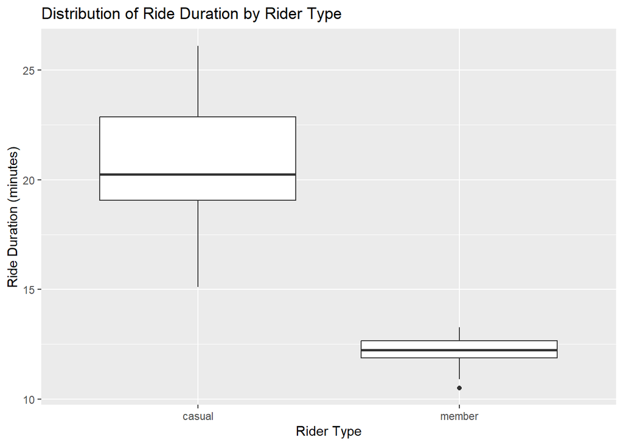

```r
#Plot
ggplot(ride_duration_summary, aes(x = member_casual, y = avg_ride_duration)) +
  geom_boxplot() +
  labs(x = "Rider Type", y = "Ride Duration (minutes)") +
  ggtitle("Distribution of Ride Duration by Rider Type")
```

Based on the output of the t-test suggests that there is a significant difference in the average ride duration between members and casual. The mean ride duration for casual is 20.68 minutes, while for members it is 12.15 minutes, with a 95% confidence interval between 7.11 and 9.94 minutes. The p-value of 3.415e-12 indicates that this difference is statistically significant, and the t-value of 12.421 with 25.002 degrees of freedom suggests a strong evidence for rejecting the null hypothesis that the true difference in means between the two groups is equal to 0. Therefore, we can conclude that there is a significant difference in the average ride duration between members and casual.

#### 2. Members and casual riders may have different ride lengths for hour of days.

```r
t.test(avg_ride_length ~ member_casual, data = ride_duration_summary)
```

```
##
##  Welch Two Sample t-test
##
## data:  avg_ride_length by member_casual
## t = 2.3662, df = 45.618, p-value = 0.02227
## alternative hypothesis: true difference in means between group casual and group member is not equal to 0
## 95 percent confidence interval:
##  0.01021111 0.12673067
## sample estimates:
## mean in group casual mean in group member
##             2.153217             2.084746
```

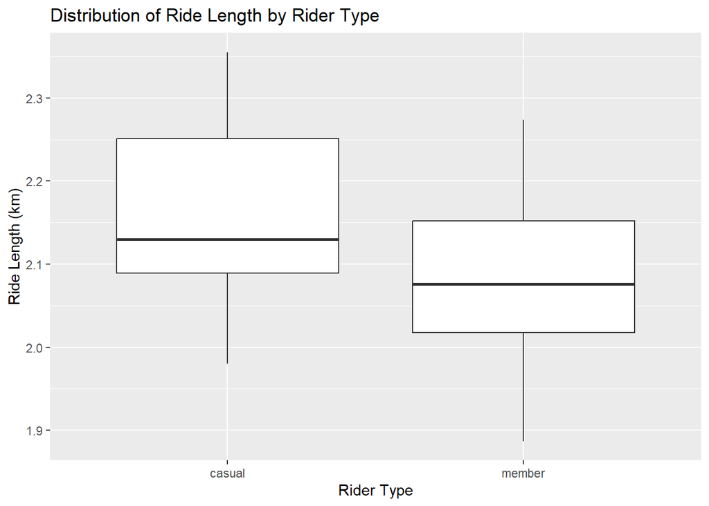

```r
#Plot
ggplot(ride_duration_summary, aes(x = member_casual, y = avg_ride_length)) +
  geom_boxplot() +
  labs(x = "Rider Type", y = "Ride Length (km)") +
  ggtitle("Distribution of Ride Length by Rider Type")
```

Based on the results of the t-test, there is evidence to suggest that there is a statistically significant difference in the mean ride length between casual and member. The p-value of 0.02227 indicates that the probability of observing such a difference by chance alone is relatively low. The confidence interval of (0.01021111, 0.12673067) suggests that the true difference in means between the two groups is likely to fall within this range 95% of the time. Therefore, it can be concluded that casual and members have different average ride lengths. Casual may be more likely to take longer rides than member.